# Tesla Tweets Analysis

Cathy Liu

2022-06-17

### Collect tweets for tesla

```r
tesla_tweets<-search_tweets(
  q="tesla",
  n=1000,
  include_rts = FALSE,
  lang="en",
  retryonratelimit = TRUE
)
names(tesla_tweets)
```

```
##  [1] "user_id"                 "status_id"
##  [3] "created_at"              "screen_name"
##  [5] "text"                    "source"
##  [7] "display_text_width"      "reply_to_status_id"
##  [9] "reply_to_user_id"        "reply_to_screen_name"
## [11] "is_quote"                "is_retweet"
## [13] "favorite_count"          "retweet_count"
## [15] "quote_count"             "reply_count"
## [17] "hashtags"                "symbols"
## [19] "urls_url"                "urls_t.co"
## [21] "urls_expanded_url"       "media_url"
## [23] "media_t.co"              "media_expanded_url"
## [25] "media_type"              "ext_media_url"
## [27] "ext_media_t.co"          "ext_media_expanded_url"
## [29] "ext_media_type"          "mentions_user_id"
```

[output cut: 30 more lines]

```r
tesla_short<-tesla_tweets%>%
  select(user_id,status_id, created_at, screen_name, text,source, favorite_count, retweet_count,media_type, location,urls_expanded_url)

tesla_short %>% write_csv("tesla_short_07_06_22.csv")
tesla_tweets1<-read_csv("tesla_short_07_06_22.csv")
```

```r
tesla_tweets2 <- read.csv("tesla_short_06_06_22.csv")
tesla_tweets3 <- read.csv("tesla_short_29_5_22.csv")
tesla_tweets4 <- read.csv("tesla_short_01_06_22.csv")
tesla_tweets5 <- read.csv("tesla_short_02_06_22.csv")
tesla_tweets6 <- read.csv("tesla_short_04_06_22.csv")

tesla_join <- tesla_tweets2 %>%
  left_join(tesla_tweets3) %>%
  left_join(tesla_tweets4) %>%
  left_join(tesla_tweets5) %>%
  left_join(tesla_tweets6)
```

[output not shown]

### Finding top 10 tweeting location

```r
tesla_location <- tesla_join %>%
  filter(!is.na(location)) %>%
  dplyr::count(location, sort = TRUE) %>%
  #mutate(percent=paste0(round(n/sum(n)*100,2),"%")) %>%
  top_n(10)
```

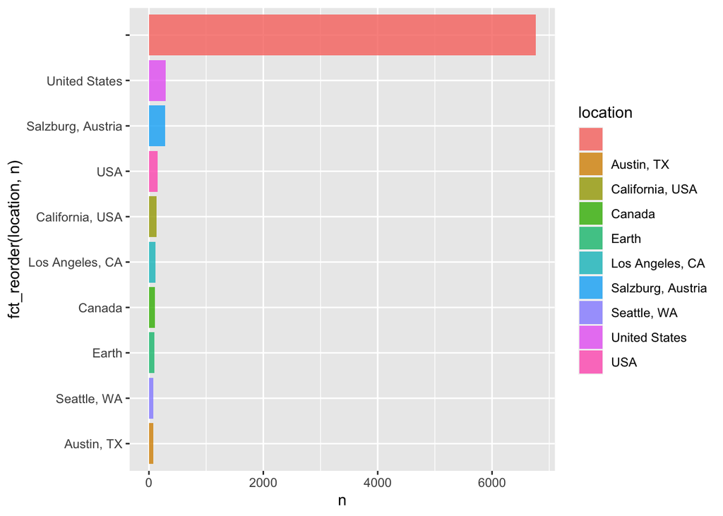

```r
tesla_location %>% ggplot(
  aes(n, fct_reorder(location, n), fill = location)) +
  geom_col(alpha = 0.8)
```

### Finding top 6 twitter users faverite mobile brand

```r
ts_mobile <- tesla_join %>% dplyr::count(source,sort = TRUE) %>%
  mutate(percent=paste0(round(n/sum(n)*100,2),"%")) %>%
  top_n(6)
```

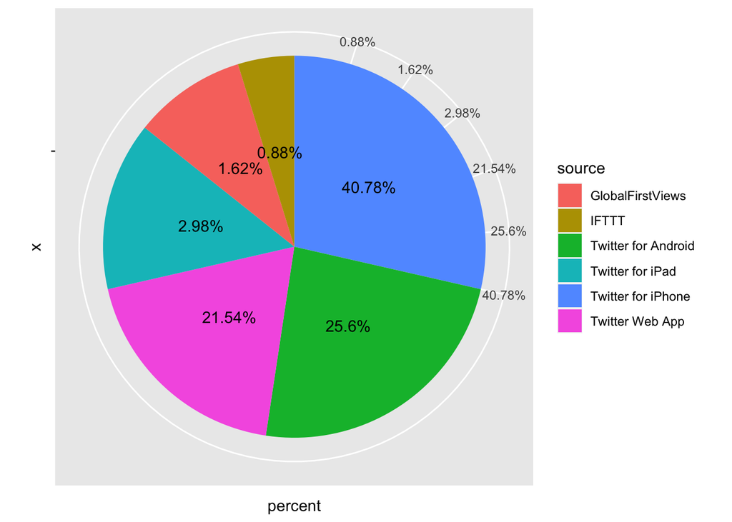

```r
ggplot(ts_mobile, aes(x = "", y = percent, fill = source)) +
  geom_col() +
  geom_text(aes(label = percent),
            position = position_stack(vjust = 0.5)) +
  coord_polar(theta = "y")
```

### Finding Top 10 retweeted tweets

```r
tesla_join %>%
  arrange(-retweet_count) %>%
  head(10) %>%
  select(created_at, screen_name, text, retweet_count)
```

```
##              created_at    screen_name
## 1  2022-06-05T17:09:43Z        RBReich
## 2  2022-06-05T18:15:49Z          Tesla
## 3  2022-06-05T03:07:11Z  Tesmanian_com
## 4  2022-06-05T12:17:01Z       mayemusk
## 5  2022-06-05T02:07:17Z charlescwcooke
## 6  2022-06-05T20:01:04Z       msainat1
## 7  2022-06-05T20:11:06Z         SRuhle
## 8  2022-06-05T05:13:44Z  teslaownersSV
## 9  2022-06-05T13:21:37Z GerberKawasaki
## 10 2022-06-05T15:59:46Z CommodusJTrump
##                                                                                                                                                                                                                                                                                                          …
## 1                                                                                                                    While Elon Musk lays off 10 percent of Tesla employees, he's set to take home $23 billion bonus. Yes, $23 billion.\n\nThe economy is somehow always great for billionaires, bad for …
## 2                                                                                                                                                                       HEPA air filter in Model Y, S and X removes &gt;99.97% of dust, pollen, mold, bacteria and any airborne particles https://t.co/I8…
## 3                                                                                                                                                                                                         Tesla Optimizes Operations by Adjusting the Hiring &amp; Layoff of Employees\n\nhttps://t.co/R6…
```

[output cut: 18 more lines]

#### Finding top 10 favourite tweets and finding the relationship between top 10 retweeted tweets and top 10 most favorite tweets

```r
tesla_join %>%
  arrange(-favorite_count) %>%
  top_n(10, favorite_count) %>%
  select(created_at, screen_name, text, favorite_count)
```

```
##              created_at    screen_name
## 1  2022-06-05T17:09:43Z        RBReich
## 2  2022-06-05T18:15:49Z          Tesla
## 3  2022-06-05T03:07:11Z  Tesmanian_com
## 4  2022-06-05T02:07:17Z charlescwcooke
## 5  2022-06-05T12:17:01Z       mayemusk
## 6  2022-06-05T13:21:37Z GerberKawasaki
## 7  2022-06-05T17:20:55Z  realMeetKevin
## 8  2022-06-05T20:08:34Z  ParikPatelCFA
## 9  2022-06-05T05:13:44Z  teslaownersSV
## 10 2022-06-05T16:09:35Z    ChrisJBakke
##                                                                                                                                                                                                             text
## 1                   While Elon Musk lays off 10 percent of Tesla employees, he's set to take home $23 billion bonus. Yes, $23 billion.\n\nThe economy is somehow always great for billionaires, bad for workers.
## 2                                                                      HEPA air filter in Model Y, S and X removes &gt;99.97% of dust, pollen, mold, bacteria and any airborne particles https://t.co/I8yCOCPbN2
## 3                                                                                                        Tesla Optimizes Operations by Adjusting the Hiring &amp; Layoff of Employees\n\nhttps://t.co/R6VCf3Eq0j
```

[output cut: 18 more lines]

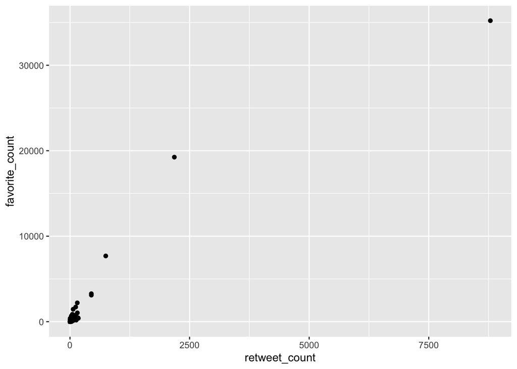

```r
tesla_retweet <- tesla_join %>%
  filter(retweet_count > 0)
ggplot(tesla_retweet, aes(x=retweet_count, y=favorite_count))+
  geom_point()
```

### Tidy dataset text

```r
remove_reg <- "&amp;|&lt;|&gt;|\\d+\\w*\\d*|#\\w+|[^\x01-\x7F]|[[:punct:]]|https\\S*"
# &amp = @
# &lt;= <
# &gt; >

#removing retweets characters
tesla_tidy <- tesla_join %>%
  filter(!str_detect(text, "^RT")) %>%
  mutate(text = str_remove_all(text, remove_reg))

#unnesting tweets
tesla_tidy_token <- tesla_tidy  %>%
  unnest_tokens(word, text) %>%
  anti_join(get_stopwords())
#keep only character-words
tesla_tidy_token<-tesla_tidy_token %>%
  filter(
    str_detect(word, "[a-z]"))
head(tesla_tidy_token$word)
```

```
## [1] "see"            "tesla"          "teslaclubsocal" "incredibly"
## [5] "fun"            "trip"
```

### Using Wordcloud to find most frequent words. And then remove meaningless words to get meaningful wordcloud.

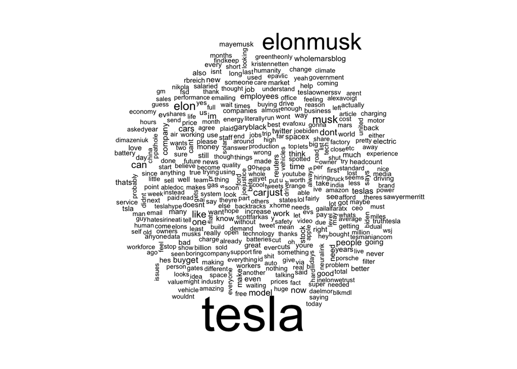

```r
tesla_tidy_token %>% dplyr::count(word) %>%
  with(wordcloud(word, n, max.words = 400))
```

```r
tesla_tidy_cloud <-tesla_tidy_token %>%
  dplyr:: count(word) %>%
  select(word, n)%>%
  filter(!word=="tesla" &
         !word=="car" &
         !word== "elonmusk")

wordcloud2(tesla_tidy_cloud,color = "random-light", backgroundColor = "black")
```

[interactive chart not shown]

### Convert tidy words to DocumentTermMatrix and Use `LDA()` function to create an LDA model.

```r
 tesla_tidy_word<- tesla_tidy_token %>%
  select(word) %>%
  filter(!word=="tesla" &
         !word=="car" &
         !word== "elonmusk"
  )

tesla_corpus <- Corpus(VectorSource(tesla_tidy_word))

tesla_dtm <- DocumentTermMatrix(tesla_corpus)
tesla_dtm
```

```
## <<DocumentTermMatrix (documents: 1, terms: 26819)>>
## Non-/sparse entries: 26819/0
## Sparsity           : 0%
## Maximal term length: 60
## Weighting          : term frequency (tf)
```

```r
tesla_lda <- LDA(tesla_dtm, k=4,control = list(seed = 1234))
tesla_lda
```

```
## A LDA_VEM topic model with 4 topics.
```

```r
tesla_topics <- tidy(tesla_lda, matrix = "beta")
tesla_topics
```

```
## # A tibble: 107,276 × 3
##    topic term                beta
##    <int> <chr>              <dbl>
##  1     1 "\"aa\","     0.0000335
##  2     2 "\"aa\","     0.00000379
##  3     3 "\"aa\","     0.0000505
##  4     4 "\"aa\","     0.0000277
##  5     1 "\"aaaa\","   0.00000324
##  6     2 "\"aaaa\","   0.00000418
##  7     3 "\"aaaa\","   0.00000528
##  8     4 "\"aaaa\","   0.00000460
##  9     1 "\"aaaand\"," 0.00000575
## 10     2 "\"aaaand\"," 0.00000212
## # … with 107,266 more rows
```

### Use beta as topic and terms, visualise the top 10 words from each topic .

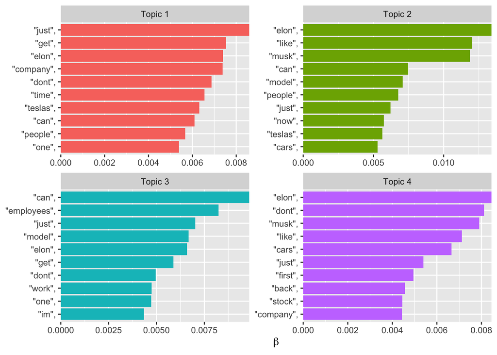

```r
tesla_topics <- tidy(tesla_lda, matrix = "beta")

tesla_topics %>%
  group_by(topic) %>%
  slice_max(beta, n=10) %>%
  ungroup()  %>%
  mutate(topic = paste("Topic", topic)) %>%
  ggplot(aes(beta, reorder_within(term, beta, topic), fill= topic)) +
  geom_col(show.legend = FALSE) +
  facet_wrap(~ topic, scales = "free") +
  scale_x_continuous(expand = c(0,0)) +
  scale_y_reordered() +
  labs(x = expression(beta), y=NULL)
```

#### The first topic is a mix topic of company and customer. The second bar chart shows a topic mixed with products and customers’ opinion. The third image shows a mixed topic of company and products. The last figure shows the topic mixed with sales and company.

### Sentiment of the text

```r
bing<- get_sentiments("bing")
nrc <- get_sentiments("nrc")
afinn <- get_sentiments("afinn")

selected_tesla_tidy<-tesla_tidy_token %>% select(created_at, screen_name, location, word, user_id)
selected_tesla_tidy<-selected_tesla_tidy%>%
  inner_join(bing) %>%
  dplyr::rename(sentiment_bing=sentiment) %>%
  inner_join(nrc)%>%
  dplyr::rename(sentiment_nrc=sentiment)
tesla_bing <- selected_tesla_tidy%>%
  dplyr::count(sentiment_bing, sort=TRUE)%>%
  mutate(percent=paste0(round(n/sum(n)*100,2),"%"))
```

### Visualization sentiment_bing

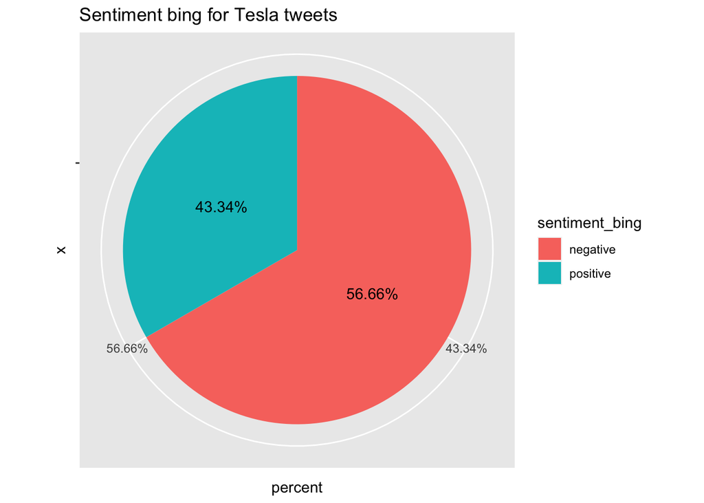

```r
counts<-selected_tesla_tidy %>% dplyr::count(sentiment_bing, sort = TRUE)
ggplot(tesla_bing, aes(x = "", y = percent, fill = sentiment_bing)) +
  geom_col() +
  geom_text(aes(label = percent),
            position = position_stack(vjust = 0.5)) +
  coord_polar(theta = "y")+
  ggtitle("Sentiment bing for Tesla tweets")
```

#### “Bing” result shows 56.66% of words are negative while only 43.34% of words are positive.

### Visualization sentiments_nrc

```r
selected_tesla_tidy%>%
  group_by(user_id)%>%
  dplyr::count(sentiment_nrc, sort=TRUE)
```

```
## # A tibble: 22,754 × 3
## # Groups:   user_id [5,983]
##    user_id sentiment_nrc     n
##      <dbl> <chr>         <int>
##  1 1.22e18 positive         37
##  2 1.22e18 negative         30
##  3 1.18e18 negative         28
##  4 1.22e18 anger            28
##  5 4.07e 8 negative         26
##  6 1.22e18 fear             25
##  7 1.22e18 joy              21
##  8 1.22e18 trust            19
##  9 1.15e18 negative         18
## 10 3.28e 7 negative         17
## # … with 22,744 more rows
```

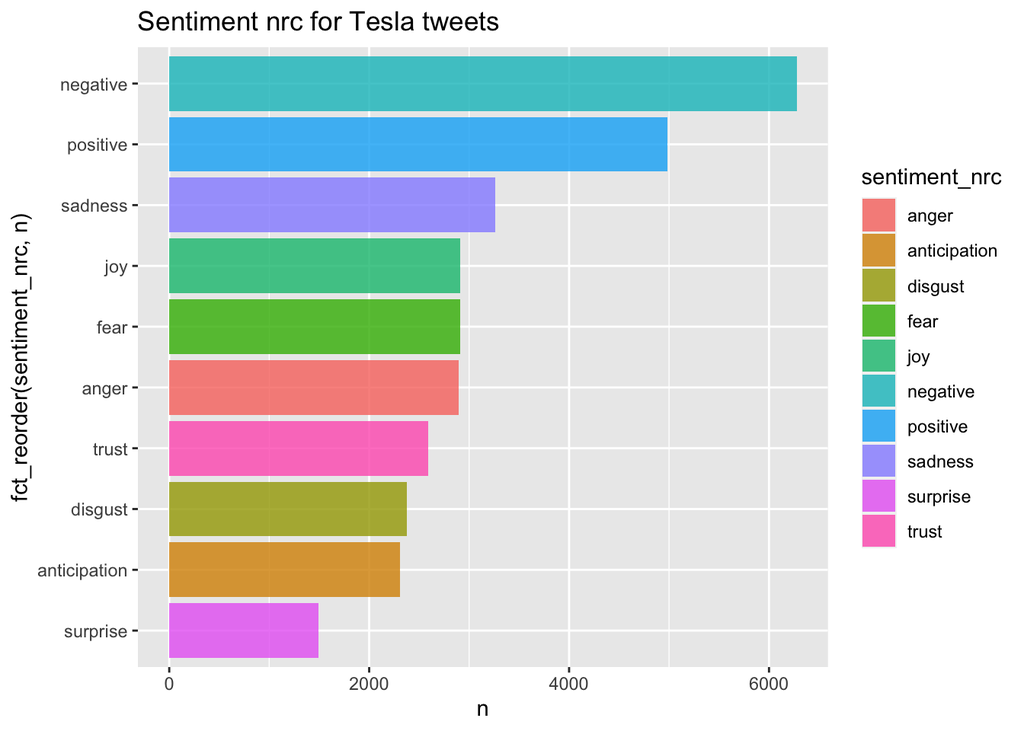

```r
count_nrc <- selected_tesla_tidy %>% dplyr::count(sentiment_nrc, sort = TRUE)

count_nrc %>% ggplot(
  aes(n,fct_reorder(sentiment_nrc, n), fill = sentiment_nrc)) +
  geom_col(alpha = 0.8) +
  ggtitle("Sentiment nrc for Tesla tweets")
```

#### The bar chart visualization shows that “negative” is more than “positive”, “sadness” is more than “joy”, “fear” and “anger” are more than “trust” and “anticipation”, “disgust” is more than “surprise”. The result is still not good but seems a little bit better than “bing” results, the difference looks less.

### Visualization sentiments_affinn

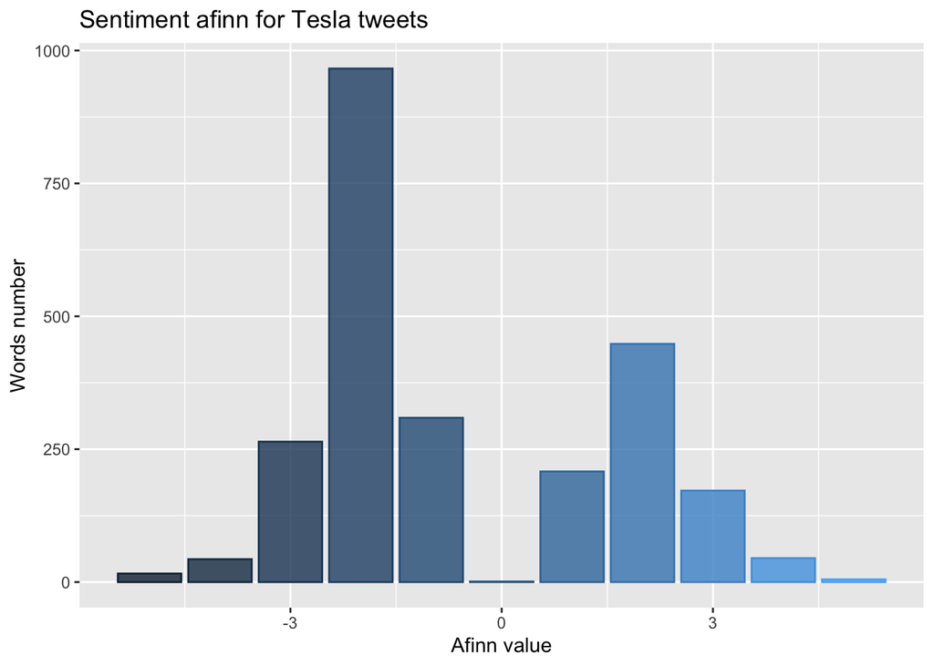

```r
count_afinn <- afinn %>% dplyr::count(value, sort = TRUE)

count_afinn %>% ggplot(aes(value, n, fill = value, color=value, col=rainbow(10))) +
  geom_col(show.legend = FALSE, alpha=0.8) +
  ggtitle("Sentiment afinn for Tesla tweets")+
  labs(x="Afinn value",y="Words number")
```